# Exploratory Data Analysis (EDA): Test 3 data

### Plot raw signal

[figure not shown]

```python
# Plot raw horizontal vibration signal: Test 1
plt.figure(figsize=(8,6))
plt.plot(df['b1x'], label='Bearing 1')
plt.plot(df['b2x'], label='Bearing 2')
plt.plot(df['b3x'], label='Bearing 3')
plt.plot(df['b4x'], label='Bearing 4')
plt.ylabel("Acceleration")
plt.xlabel("Down-sampled from 20 kHz to 2 kHz")
plt.title("Test 3: Horizontal vibration signal")
plt.tight_layout()
plt.legend()
plt.show()
```

### Absolute Mean Signal

```python
b1x_means = test_3.apply(abs).groupby(['measurement_id']).mean()
```

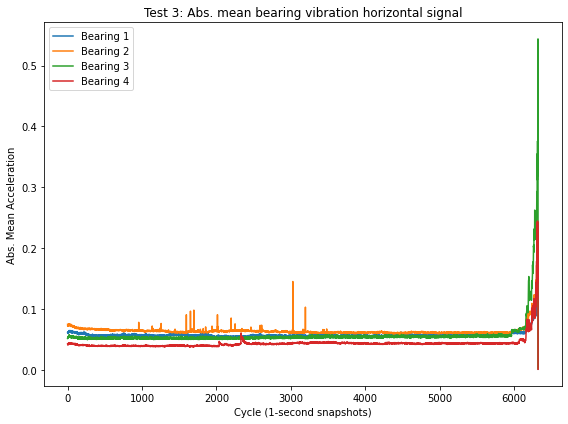

```python
plt.figure(figsize=(8,6))
plt.plot(b1x_means['b1x'], label='Bearing 1')
plt.plot(b1x_means['b2x'], label='Bearing 2')
plt.plot(b1x_means['b3x'], label='Bearing 3')
plt.plot(b1x_means['b4x'], label='Bearing 4')
plt.ylabel("Abs. Mean Acceleration")
plt.xlabel("Cycle (1-second snapshots)")
plt.title("Test 3: Abs. mean bearing vibration horizontal signal")
plt.tight_layout()
plt.legend()
plt.show()
```

### RMS

"We know from Qiu et al that the RMS value of the accelerometer should be a good indicator that something related to the bearing is failing. Let's try to plot the RMS aggregated per 1s snapshot over the entire span of Set No 1.

If the mean is zero, RMS is the same as standard deviation, as seen from their definitions below. Our mean might not be exactly zero, but close enough."

**Source:** https://www.kaggle.com/code/andersgb/nasa-bearing-dataset-outlier-detection

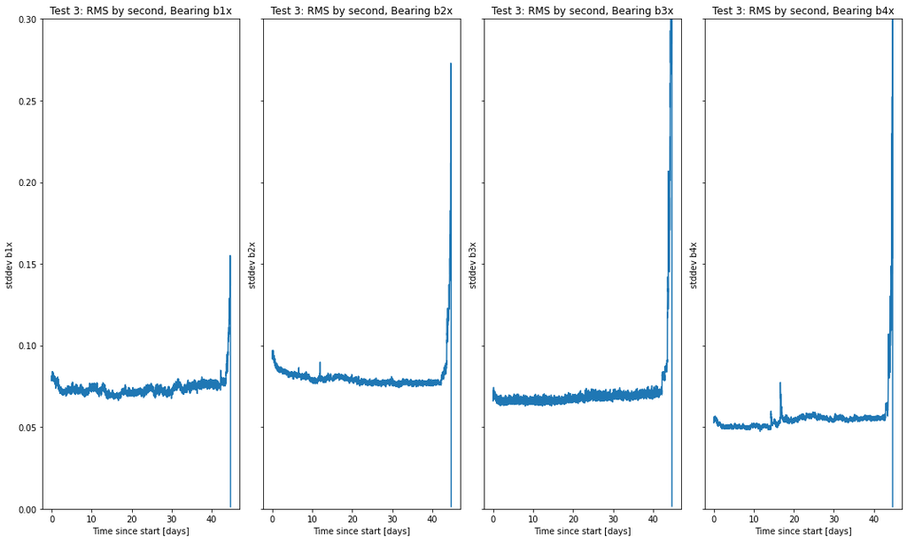

```python
# Source: https://www.kaggle.com/code/andersgb/nasa-bearing-dataset-outlier-detection
fig, axes = plt.subplots(nrows=1, ncols=4, sharey=True, figsize=(15, 9))
x = test_3.groupby("measurement_id")["time"].head(1) / (3600 * 24)
for (sensor, ax) in zip(["b1x", "b2x", "b3x", "b4x"], axes.ravel()):
    y = test_3.groupby("measurement_id")[sensor].std(ddof=0)
    ax.set_ylim([0, 0.3])
    ax.plot(x, y)
    ax.set_ylabel(f"stddev {sensor}")
    ax.set_xlabel("Time since start [days]")
    ax.title.set_text(f"Test 3: RMS by second, Bearing {sensor}")
plt.tight_layout()
plt.show()
```

### Kurtosis

From "Estimation of Remaining Useful Life of Ball Bearings using Data Driven Methodologies" paper (https://ieeexplore.ieee.org/document/6299548).

Sutrisno, Oh, et. al., found a high correlation between the moving average of kurtosis and time -- a strong monotonic relationship, indicating that kurtosis is a good feature for prognostics.

```python
df = pd.DataFrame()
for file in ['ts_T3_b1x','ts_T3_b2x','ts_T3_b3x','ts_T3_b4x']:
    temp = pd.read_csv('Data/IMS/TS/' + file + '_ds10.csv')
    temp['bearing'] = file
    df = pd.concat([df, temp], axis=0, ignore_index=True)
```

```python
b1x_kurt = df[df['bearing']=='ts_T3_b1x']['ktosis']
b2x_kurt = df[df['bearing']=='ts_T3_b2x']['ktosis'].reset_index(drop=True)
b3x_kurt = df[df['bearing']=='ts_T3_b3x']['ktosis'].reset_index(drop=True)
b4x_kurt = df[df['bearing']=='ts_T3_b4x']['ktosis'].reset_index(drop=True)
```

```python
kurt = pd.concat([b1x_kurt, b2x_kurt, b3x_kurt, b4x_kurt], axis=1)
kurt.columns = ['b1', 'b2', 'b3', 'b4']
kurt.head()
```

|  | b1 | b2 | b3 | b4 |
| --- | --- | --- | --- | --- |
| 0 | 0.973177 | 0.092757 | 0.016707 | 0.194799 |
| 1 | 0.581787 | -0.058764 | 0.111316 | 0.231554 |
| 2 | 0.285371 | -0.092261 | -0.087568 | 0.289236 |
| 3 | 0.667476 | -0.036045 | -0.128656 | 0.157656 |
| 4 | 0.057404 | -0.201248 | 0.006248 | 0.286740 |

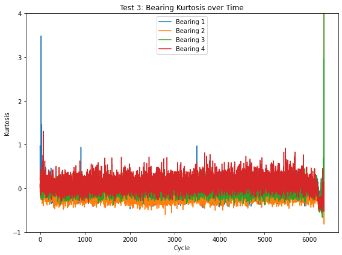

```python
plt.figure(figsize=(8,6))
plt.ylim((-1, 4))
plt.plot(kurt['b1'], label='Bearing 1')
plt.plot(kurt['b2'], label='Bearing 2')
plt.plot(kurt['b3'], label='Bearing 3')
plt.plot(kurt['b4'], label='Bearing 4')
plt.ylabel("Kurtosis")
plt.xlabel("Cycle")
plt.title("Test 3: Bearing Kurtosis over Time")
plt.tight_layout()
plt.legend()
plt.show()
```

```python
#Exponantial Moving Average of Kurtosis
kurt['b1_EMA'] = kurt['b1'].ewm(span=40,adjust=False).mean()
kurt['b2_EMA'] = kurt['b2'].ewm(span=40,adjust=False).mean()
kurt['b3_EMA'] = kurt['b3'].ewm(span=40,adjust=False).mean()
kurt['b4_EMA'] = kurt['b4'].ewm(span=40,adjust=False).mean()
```

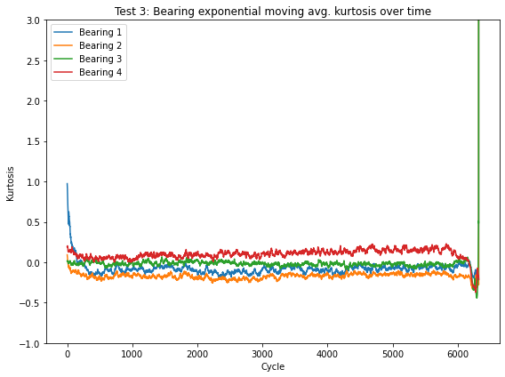

```python
plt.figure(figsize=(8,6))
plt.ylim((-1,3))
plt.plot(kurt['b1_EMA'], label='Bearing 1')
plt.plot(kurt['b2_EMA'], label='Bearing 2')
plt.plot(kurt['b3_EMA'], label='Bearing 3')
plt.plot(kurt['b4_EMA'], label='Bearing 4')
plt.ylabel("Kurtosis")
plt.xlabel("Cycle")
plt.title("Test 3: Bearing exponential moving avg. kurtosis over time")
plt.tight_layout()
plt.legend()
plt.show()
```

**Source:** https://www.kaggle.com/code/furkancitil/nasa-bearing-dataset-rul-prediction

"Moving average filter (also known as rolling average, running average) is a time series filter which calculates running weighted sum of time series. Simple moving average, cumulative moving average ,and exponantiel moving average methods are applied to feature data for smoothing. After comparing the results on a graph, it is concluded that EMA(40) is best option for filtering because it best reflecting the actual moves of the real data."

```python
ma = pd.DataFrame()

# Simple moving average (SMA)
ma['Kurtosis'] = kurt['b3']
ma['SMA'] = kurt['b3'].rolling(window=5).mean()
ma['Cycle'] = kurt.index

#Cumulative Moving Average
ma['CMA'] = kurt['b3'].expanding(min_periods=10).mean()

#Exponantial Moving Average
ma['EMA'] = kurt['b3'].ewm(span=40,adjust=False).mean()
```

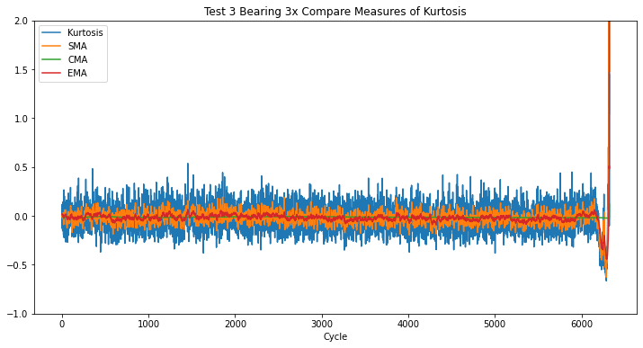

```python
ma.plot(x="Cycle", y= ['Kurtosis','SMA','CMA','EMA'],
        figsize=(12,6),
        ylim=(-1,2),
        title="Test 3 Bearing 3x Compare Measures of Kurtosis")
```